# RNAseq Mouse Kidney

Uwe Schwartz

02/12/2019

## Dependencies & Libraries

#### Load packages

```r
library(DESeq2)
library(RColorBrewer)
library(ggplot2)
library(ggrepel)
library(stringr)
library("pheatmap")
palette(unique(c(brewer.pal(9,"Set1"),brewer.pal(8,"Set2"))))
```

## Import data

First load and prepare count table. Subsequently a meta-data table is generated.

```r
# load count table from featureCounts
count.table<-read.delim("counts/count_table.txt", skip=1)

names1<-sapply(strsplit(colnames(count.table[,7:ncol(count.table)]),
                        split = ".", fixed = T), function(x)
                            paste(x[(grep("bams", x)+1)]))
colnames(count.table)[7:ncol(count.table)]<-names1
counts<-count.table[,7:ncol(count.table)]
rownames(counts)<-as.character(count.table$Geneid)


## data frame annotation annotation

replica<-rep(paste0("R",1:6),2)

mouse<-sapply(strsplit(colnames(counts),split = "_"),
                           function(x) x[2])

condition<-sapply(strsplit(colnames(counts),split = "_"),
                           function(x) x[3])

meta.DATA<-data.frame(ID=colnames(counts),replica,
                      condition,mouse,
                      row.names = colnames(counts))
meta.DATA
```

```
##                              ID replica condition mouse
## 01_29051_WT_S1   01_29051_WT_S1      R1        WT 29051
## 02_29052_WT_S2   02_29052_WT_S2      R2        WT 29052
## 03_29031_WT_S3   03_29031_WT_S3      R3        WT 29031
## 04_29032_WT_S4   04_29032_WT_S4      R4        WT 29032
## 05_29033_WT_S5   05_29033_WT_S5      R5        WT 29033
## 06_29034_WT_S6   06_29034_WT_S6      R6        WT 29034
## 07_28961_KO_S7   07_28961_KO_S7      R1        KO 28961
## 08_28962_KO_S8   08_28962_KO_S8      R2        KO 28962
## 09_29183_KO_S9   09_29183_KO_S9      R3        KO 29183
## 10_29182_KO_S10 10_29182_KO_S10      R4        KO 29182
## 11_29181_KO_S11 11_29181_KO_S11      R5        KO 29181
## 12_29185_KO_S12 12_29185_KO_S12      R6        KO 29185
```

```r
## create DESeq obj
dds.obj <- DESeqDataSetFromMatrix(countData = counts,
                                   colData = meta.DATA,
                                   design= ~condition)
```

## exploratory analysis

Exploratory analysis was performed to get an overview about the quality of the samples and make replica clustering. First the data is transformed using the rlog function within the DESeq2 package. The function rlog, stands for regularized log, transforming the original count data to the log2 scale by fitting a model with a term for each sample and a prior distribution on the coefficients which is estimated from the data.

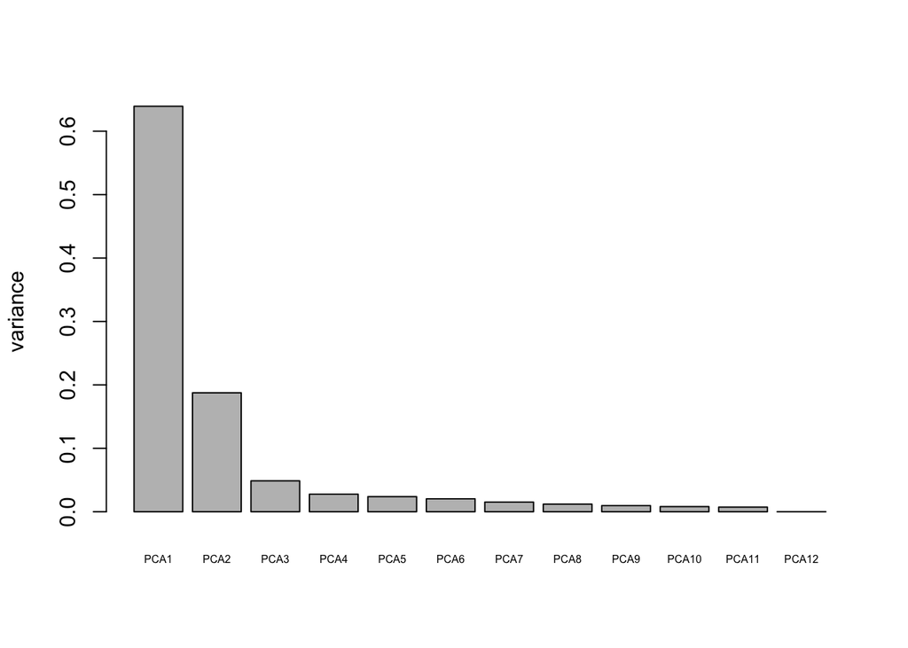

```r
# rlog tranformation
rld<-rlog(dds.obj,blind = T)

## plot PCA

### variables
my.pal<-c(brewer.pal(9,"Set1"))
object<-rld
ntop=500
var.col<-"condition"
var.symb<-"replica"
intgroup=c(var.col,var.symb )
returnData=F
###

rv <- rowVars(assay(object))
select <- order(rv, decreasing = TRUE)[seq_len(min(ntop,length(rv)))]

pca <- prcomp(t(assay(object)[select, ]))
percentVar <- pca$sdev^2/sum(pca$sdev^2)


# varaince covered by PC
barplot(percentVar, names.arg = paste0("PCA", 1:length(percentVar)),
          ylab="variance", cex.names = 0.5)
```

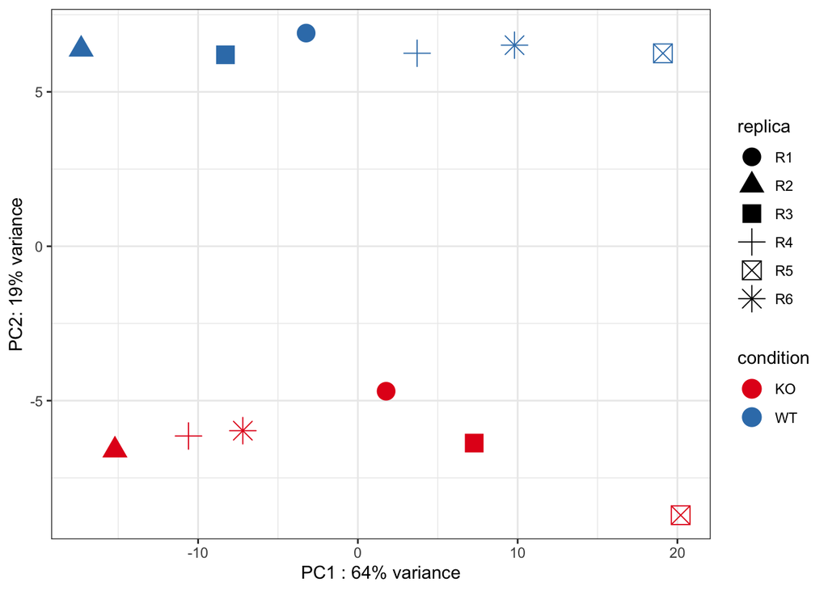

```r
intgroup.df <- as.data.frame(colData(object)[,intgroup,drop = FALSE])
group <- if (length(intgroup) > 1) {
  factor(apply(intgroup.df, 1, paste, collapse = " : "))
} else {
  colData(object)[[intgroup]]
}

# show first two components
i=1
d <- data.frame(PCx = pca$x[, i], PCy = pca$x[, i+1], group = group,
                  intgroup.df, name=colData(dds.obj)[colnames(object),"ID"])

g<-ggplot(data = d, aes_string(x = "PCx", y = "PCy", color = var.col,
                               shape=var.symb)) +
      geom_point(size = 5) + theme_bw()+xlab(paste0("PC",i," : ",
                                round(percentVar[i] * 100), "% variance"))+
      ylab(paste0("PC",i+1,": ", round(percentVar[i+1] *100),
                  "% variance"))+scale_color_manual(values=my.pal)
print(g)
```

### heatmaps

First sample wise similarity clutstering was performed and then the 500 most variable genes were clustered based on their expression levels

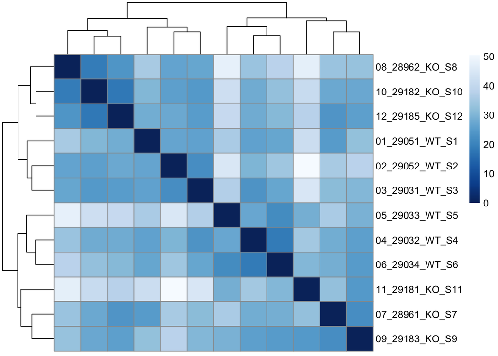

```r
## similarity clustering
colors <- colorRampPalette( rev(brewer.pal(9, "Blues")) )(255)

sampleDists <- dist(t(assay(rld)))

sampleDistMatrix <- as.matrix( sampleDists )
rownames(sampleDistMatrix) <-rld$ID
colnames(sampleDistMatrix) <- NULL

pheatmap(sampleDistMatrix,
         clustering_distance_rows = sampleDists,
         clustering_distance_cols = sampleDists,
         col = colors)
```

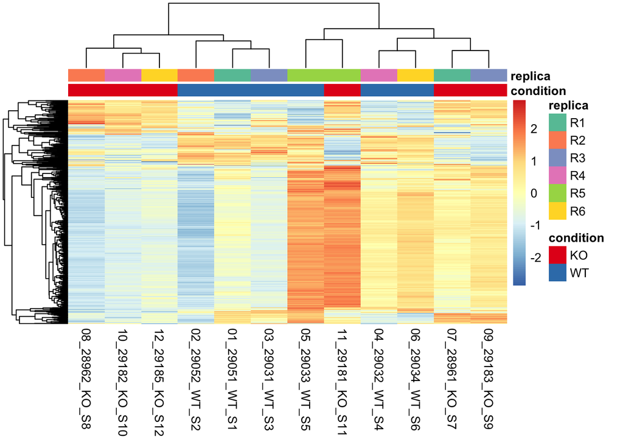

```r
## 500 most variable genes

rv <- rowVars(assay(rld))
select <- order(rv, decreasing = TRUE)[1:500]
mat <-assay(rld)[select,]

anno<-as.data.frame(colData(rld)[,c(var.col,var.symb)])

anno_colors=list()

lv.col<-levels(colData(dds.obj)[,var.col])
anno_colors[[var.col]]<-c(brewer.pal(length(lv.col), "Set1"))[1:length(lv.col)]
names(anno_colors[[var.col]])<-lv.col

lv.symb<-levels(colData(dds.obj)[,var.symb])
anno_colors[[var.symb]]<-c(brewer.pal(length(lv.symb), "Set2"))
names(anno_colors[[var.symb]])<-lv.symb

pheatmap(mat, annotation_col = anno,scale="row", show_rownames = F,
               annotation_colors =anno_colors)
```

The 500 most variable genes cluster mainly based on a gene set which are specific for R5. A subset of the top variable genes correspond to “WT” and “KO” specific gene signatures (top gene cluster).